# RT-QuIC vs Nano-QuIC Diagnostic Performance in Norwegian Cervids

Author

Gage Rowden

Published

May 5, 2026

## Background

We compare two prion-detection assays — **RT-QuIC** and **Nano-QuIC** — across three Norwegian cervid species (moose, reindeer, red deer) and three tissues (brainstem, lymph node, skin). The goal is to identify, for each species/tissue combination, the **assay**, **sample dilution**, and **reaction time cutoff** that best discriminates ELISA-positive from ELISA-negative animals.

## Metric Reduction via PCA

Each QuIC reaction produces three correlated kinetic metrics:

- **MPR** — Maxpoint Ratio
- **MS** — Maxpoint Slope
- **AUC** — Area Under the fluorescence Curve

Because these metrics are highly collinear (see correlation plot below), choosing a single “best” metric for diagnosis would be arbitrary. Instead we run **principal component analysis** on the three metrics (scaled) and use **PC1** — which captures the dominant shared signal — as a unified diagnostic score for downstream ROC analysis.

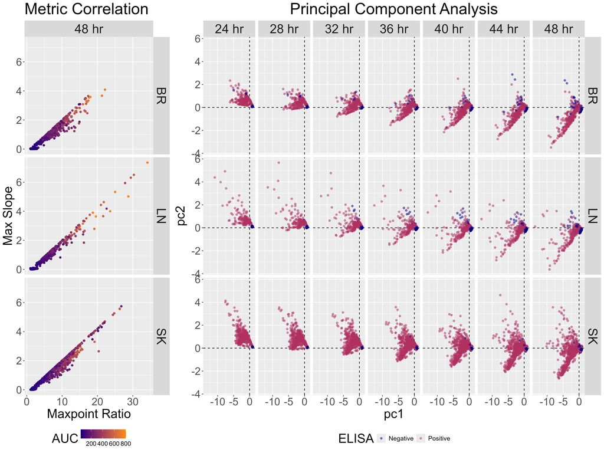

Left: pairwise correlation of MPR vs MS, colored by AUC, faceted by tissue (48 hr cutoff). Right: PC1 vs PC2 scores colored by ELISA status.

### Time-to-Threshold Distributions

We observed that a clear separation in the times-to-threshold for each sample type, and so time-cutoffs were applied to the results starting at 24hr and ending at 48hr, incrementing by 4hr.

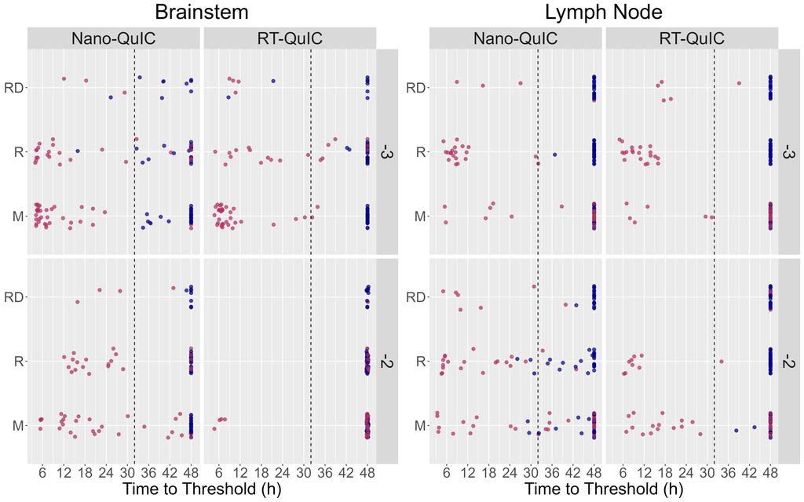

Time-to-threshold (TtT) by species, faceted by assay (columns) and dilution (rows), for brainstem and lymph node tissues at the 48 hr cutoff. Dashed line marks the 32 hr which on average showed to be the most diagnostically consistent time cutoff for any given combination of tissue, assay, and dilution factor.